# HW-2

## Chapter-3: Excercise

### 3.4.(a)

Answer: We would expect the RSS of cubic model to be lower than the linear model due to possible overfit by adding predictors.

### 3.4.(b)

Answer: We would expect the test RSS of cubic model to be lower than the linear model because of worse performance as a result of higher variance.

### 3.4.(c)

Answer: If the true relationship is non-linear, we would expect the train RSS of cubic model to be lower than linear model. This is becasue cubic model is more flexible and can better fit the nonlinear patterns in the data.

### 3.4.(d)

Answer: There is no enough information to tell because we do not know how far away the relationship is from the linear. The more nonlinear it is, the test RSS of cubic model is lower than that of linear model. The more it is close to linear relationship, the higher the test RSS is compared with linear model due to increased variance of the cubic model.

### 3.7

$$ R^2 = \frac{\text{SSR}}{\text{SST}} = \frac{\sum_i (\hat{y}_i - \bar{y})^2}{\sum_i (y_i - \bar{y})^2} $$

Assuming x_bar = y_bar = 0, the slope of the regression line is:

$$ \hat{\beta}_1 = \frac{\sum_i x_i y_i}{\sum_i x_i^2} $$

The fitted values are:

$$ \hat{y}_i = \hat{\beta}_1 x_i $$

Then the regression sum of squares (SSR) is:

$$ \text{SSR} = \sum_i (\hat{y}_i - \bar{y})^2 = \sum_i (\hat{\beta}_1 x_i)^2 = \hat{\beta}_1^2 \sum_i x_i^2 $$

$$ \text{SSR} = \left(\frac{\sum_i x_i y_i}{\sum_i x_i^2}\right)^2 \sum_i x_i^2 = \frac{\left(\sum_i x_i y_i\right)^2}{\sum_i x_i^2} $$

The SST is:

$$ \text{SST} = \sum_i (y_i - \bar{y})^2 = \sum_i y_i^2 $$

So ( R^2 ) is:

$$ R^2 = \frac{\text{SSR}}{\text{SST}} = \frac{\left(\sum_i x_i y_i\right)^2 / \sum_i x_i^2}{\sum_i y_i^2} = \frac{\left(\sum_i x_i y_i\right)^2}{\sum_i x_i^2 \sum_i y_i^2} = \text{Corr}(X,Y)^2 $$

$$ R^2 = \text{Corr}(Y, \hat{Y})^2 $$

$$ \hat{Y} = \hat{\beta}_0 + \hat{\beta}_1 X $$ $$ \bar{Y} = \frac{1}{n} \sum_{i=1}^n Y_i $$ $$ R^2 = 1 - \frac{\text{RSS}}{\text{TSS}} $$ $$ \text{RSS} = \sum_{i=1}^n (Y_i - \hat{Y}_i)^2, \quad \text{TSS} = \sum_{i=1}^n (Y_i - \bar{Y})^2 $$

$$ \sum_{i=1}^n (Y_i - \hat{Y}_i) = 0 $$

$$ \sum_{i=1}^n (\hat{Y}_i - \bar{Y})^2 = \frac{(\sum_{i=1}^n (X_i - \bar{X})(Y_i - \bar{Y}))^2}{\sum_{i=1}^n (X_i - \bar{X})^2} $$

$$ R^2 = \frac{\text{Explained Sum of Squares}}{\text{Total Sum of Squares}} = \frac{\sum_{i=1}^n (\hat{Y}_i - \bar{Y})^2}{\sum_{i=1}^n (Y_i - \bar{Y})^2} $$

$$ R^2 = \frac{\left( \sum_{i=1}^n (X_i - \bar{X})(Y_i - \bar{Y}) \right)^2}{\sum_{i=1}^n (X_i - \bar{X})^2 \sum_{i=1}^n (Y_i - \bar{Y})^2} $$

$$ \text{Corr}(X, Y) = \frac{\sum_{i=1}^n (X_i - \bar{X})(Y_i - \bar{Y})}{\sqrt{\sum_{i=1}^n (X_i - \bar{X})^2} \sqrt{\sum_{i=1}^n (Y_i - \bar{Y})^2}} $$

$$ \text{Corr}(X, Y)^2 = \frac{\left( \sum_{i=1}^n (X_i - \bar{X})(Y_i - \bar{Y}) \right)^2}{\sum_{i=1}^n (X_i - \bar{X})^2 \sum_{i=1}^n (Y_i - \bar{Y})^2} = R^2 $$

### 3.9 (a)

```python
import pandas as pd
import matplotlib.pyplot as plt
import seaborn as sns
```

```python
# load Auto dataset
url = "https://archive.ics.uci.edu/ml/machine-learning-databases/auto-mpg/auto-mpg.data"
columns = ["mpg","cylinders","displacement","horsepower",
           "weight","acceleration","year","origin","name"]

auto = pd.read_csv(url, delim_whitespace=True, names=columns, na_values="?")
auto.head()
```

|  | mpg | cylinders | displacement | horsepower | weight | acceleration | year | origin | name |
| --- | --- | --- | --- | --- | --- | --- | --- | --- | --- |
| 0 | 18.0 | 8 | 307.0 | 130.0 | 3504.0 | 12.0 | 70 | 1 | chevrolet chevelle malibu |
| 1 | 15.0 | 8 | 350.0 | 165.0 | 3693.0 | 11.5 | 70 | 1 | buick skylark 320 |
| 2 | 18.0 | 8 | 318.0 | 150.0 | 3436.0 | 11.0 | 70 | 1 | plymouth satellite |
| 3 | 16.0 | 8 | 304.0 | 150.0 | 3433.0 | 12.0 | 70 | 1 | amc rebel sst |
| 4 | 17.0 | 8 | 302.0 | 140.0 | 3449.0 | 10.5 | 70 | 1 | ford torino |

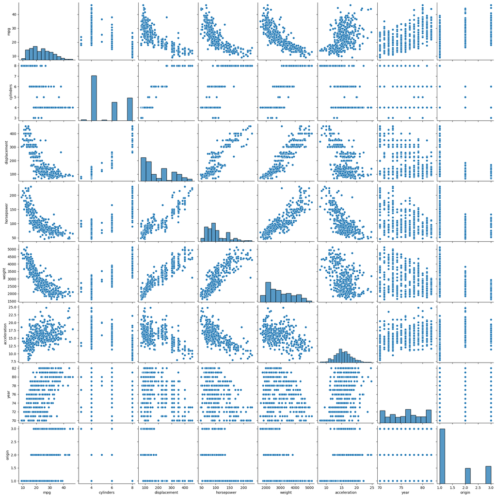

```python
# create scatterplot on all variables
sns.pairplot(auto)
```

### 3.9 (b)

```python
# compute matrix of correlations of all variables
df = auto.drop(columns='name')
df.corr()
```

|  | mpg | cylinders | displacement | horsepower | weight | acceleration | year | origin |
| --- | --- | --- | --- | --- | --- | --- | --- | --- |
| mpg | 1.000000 | -0.775396 | -0.804203 | -0.778427 | -0.831741 | 0.420289 | 0.579267 | 0.563450 |
| cylinders | -0.775396 | 1.000000 | 0.950721 | 0.842983 | 0.896017 | -0.505419 | -0.348746 | -0.562543 |
| displacement | -0.804203 | 0.950721 | 1.000000 | 0.897257 | 0.932824 | -0.543684 | -0.370164 | -0.609409 |
| horsepower | -0.778427 | 0.842983 | 0.897257 | 1.000000 | 0.864538 | -0.689196 | -0.416361 | -0.455171 |
| weight | -0.831741 | 0.896017 | 0.932824 | 0.864538 | 1.000000 | -0.417457 | -0.306564 | -0.581024 |
| acceleration | 0.420289 | -0.505419 | -0.543684 | -0.689196 | -0.417457 | 1.000000 | 0.288137 | 0.205873 |
| year | 0.579267 | -0.348746 | -0.370164 | -0.416361 | -0.306564 | 0.288137 | 1.000000 | 0.180662 |
| origin | 0.563450 | -0.562543 | -0.609409 | -0.455171 | -0.581024 | 0.205873 | 0.180662 | 1.000000 |

### 3.9 (c)

```python
import statsmodels.api as sm
import numpy as np
```

```python
# multiple linear regression
df = df.dropna()
x = df.drop(columns=['mpg'])
x = sm.add_constant(x) # add constant
y = df['mpg']
mlr_model = sm.OLS(y, x).fit() # fit the model

# summarize model
mlr_model.summary()
```

OLS Regression Results

| Dep. Variable: | mpg | R-squared: | 0.821 |
| --- | --- | --- | --- |
| Model: | OLS | Adj. R-squared: | 0.818 |
| Method: | Least Squares | F-statistic: | 252.4 |
| Date: | Tue, 17 Feb 2026 | Prob (F-statistic): | 2.04e-139 |
| Time: | 15:14:12 | Log-Likelihood: | -1023.5 |
| No. Observations: | 392 | AIC: | 2063. |
| Df Residuals: | 384 | BIC: | 2095. |
| Df Model: | 7 |  |  |
| Covariance Type: | nonrobust |  |  |

|  | coef | std err | t | P>\|t\| | [0.025 | 0.975] |
| --- | --- | --- | --- | --- | --- | --- |
| const | -17.2184 | 4.644 | -3.707 | 0.000 | -26.350 | -8.087 |
| cylinders | -0.4934 | 0.323 | -1.526 | 0.128 | -1.129 | 0.142 |
| displacement | 0.0199 | 0.008 | 2.647 | 0.008 | 0.005 | 0.035 |
| horsepower | -0.0170 | 0.014 | -1.230 | 0.220 | -0.044 | 0.010 |
| weight | -0.0065 | 0.001 | -9.929 | 0.000 | -0.008 | -0.005 |
| acceleration | 0.0806 | 0.099 | 0.815 | 0.415 | -0.114 | 0.275 |
| year | 0.7508 | 0.051 | 14.729 | 0.000 | 0.651 | 0.851 |
| origin | 1.4261 | 0.278 | 5.127 | 0.000 | 0.879 | 1.973 |

| Omnibus: | 31.906 | Durbin-Watson: | 1.309 |
| --- | --- | --- | --- |
| Prob(Omnibus): | 0.000 | Jarque-Bera (JB): | 53.100 |
| Skew: | 0.529 | Prob(JB): | 2.95e-12 |
| Kurtosis: | 4.460 | Cond. No. | 8.59e+04 |

Notes:  
[1] Standard Errors assume that the covariance matrix of the errors is correctly specified.  
[2] The condition number is large, 8.59e+04. This might indicate that there are  
strong multicollinearity or other numerical problems.

### 3.9 (c)

```python
from statsmodels.stats.anova import anova_lm
import statsmodels.formula.api as smf
```

```python
# rebuild the model using smf
mlr_model = smf.ols(
    'mpg ~ cylinders + displacement + horsepower + weight + acceleration + year + origin',
    data=df
).fit()

# anova_lm
anova_lm(mlr_model)
```

|  | df | sum_sq | mean_sq | F | PR(>F) |
| --- | --- | --- | --- | --- | --- |
| cylinders | 1.0 | 14403.083079 | 14403.083079 | 1300.683788 | 2.319511e-125 |
| displacement | 1.0 | 1073.344025 | 1073.344025 | 96.929329 | 1.530906e-20 |
| horsepower | 1.0 | 403.408069 | 403.408069 | 36.430140 | 3.731128e-09 |
| weight | 1.0 | 975.724953 | 975.724953 | 88.113748 | 5.544461e-19 |
| acceleration | 1.0 | 0.966071 | 0.966071 | 0.087242 | 7.678728e-01 |
| year | 1.0 | 2419.120249 | 2419.120249 | 218.460900 | 1.875281e-39 |
| origin | 1.0 | 291.134494 | 291.134494 | 26.291171 | 4.665681e-07 |
| Residual | 384.0 | 4252.212530 | 11.073470 | NaN | NaN |

```python
mlr_model.summary()
```

OLS Regression Results

| Dep. Variable: | mpg | R-squared: | 0.821 |
| --- | --- | --- | --- |
| Model: | OLS | Adj. R-squared: | 0.818 |
| Method: | Least Squares | F-statistic: | 252.4 |
| Date: | Tue, 17 Feb 2026 | Prob (F-statistic): | 2.04e-139 |
| Time: | 15:30:43 | Log-Likelihood: | -1023.5 |
| No. Observations: | 392 | AIC: | 2063. |
| Df Residuals: | 384 | BIC: | 2095. |
| Df Model: | 7 |  |  |
| Covariance Type: | nonrobust |  |  |

|  | coef | std err | t | P>\|t\| | [0.025 | 0.975] |
| --- | --- | --- | --- | --- | --- | --- |
| Intercept | -17.2184 | 4.644 | -3.707 | 0.000 | -26.350 | -8.087 |
| cylinders | -0.4934 | 0.323 | -1.526 | 0.128 | -1.129 | 0.142 |
| displacement | 0.0199 | 0.008 | 2.647 | 0.008 | 0.005 | 0.035 |
| horsepower | -0.0170 | 0.014 | -1.230 | 0.220 | -0.044 | 0.010 |
| weight | -0.0065 | 0.001 | -9.929 | 0.000 | -0.008 | -0.005 |
| acceleration | 0.0806 | 0.099 | 0.815 | 0.415 | -0.114 | 0.275 |
| year | 0.7508 | 0.051 | 14.729 | 0.000 | 0.651 | 0.851 |
| origin | 1.4261 | 0.278 | 5.127 | 0.000 | 0.879 | 1.973 |

| Omnibus: | 31.906 | Durbin-Watson: | 1.309 |
| --- | --- | --- | --- |
| Prob(Omnibus): | 0.000 | Jarque-Bera (JB): | 53.100 |
| Skew: | 0.529 | Prob(JB): | 2.95e-12 |
| Kurtosis: | 4.460 | Cond. No. | 8.59e+04 |

Notes:  
[1] Standard Errors assume that the covariance matrix of the errors is correctly specified.  
[2] The condition number is large, 8.59e+04. This might indicate that there are  
strong multicollinearity or other numerical problems.

There is a statistically significant relationship between the most predictors and the response mpg. Only acceleration shows insignificant relationship. The coefficient for the year variable (0.75) suggests a car model of more recent years are built with higher mpg. With each model year advanced, the mpg increases by 0.75 assuming holiding other variables the same.

### 3.9 (d)

```python
import matplotlib.pyplot as plt
```

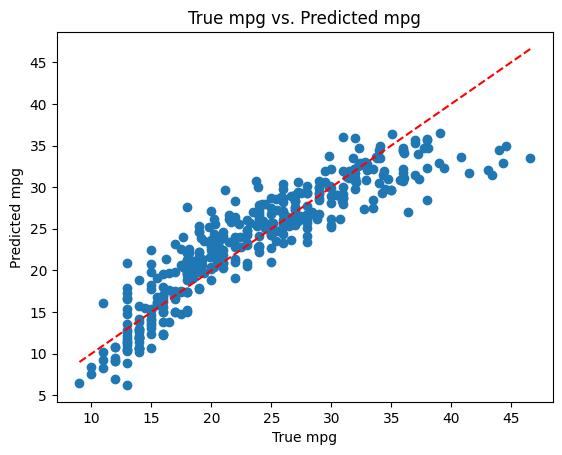

```python
# plot y pred vs. y

# generate predicted values
y_pred = mlr_model.fittedvalues

plt.scatter(y, y_pred)
# add a diagonal line indicating perfect prediction
line = [y.min(), y.max()]
plt.plot(line, line, '--', color='red')  # red dashed line
plt.xlabel('True mpg')
plt.ylabel('Predicted mpg')
plt.title('True mpg vs. Predicted mpg')
```

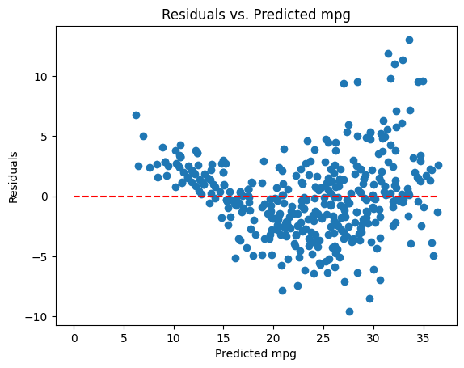

```python
# plot residual plot
residuals = mlr_model.resid
plt.scatter(y_pred, residuals)
plt.plot([0,max(y_pred)],[0,0], '--', color='red')
plt.xlabel('Predicted mpg')
plt.ylabel('Residuals')
plt.title('Residuals vs. Predicted mpg')
```

```python
from statsmodels.graphics.regressionplots import plot_leverage_resid2
```

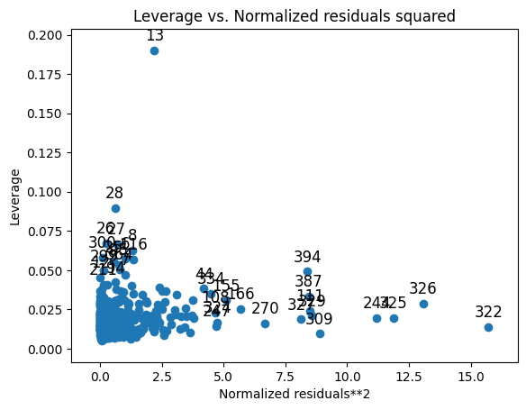

```python
# leverage plot
fig = plot_leverage_resid2(mlr_model)
```

From the leverage plot, along with residual plot and the fitted plot, most observations have low leverage and small residuals (clustered near bottom left 0,0), suggesting most predictors and responses are not outliers. Observation 13, 28, 394 has high leverage, which could influence the predicted reesult. Points on the right side of the graph such as 322, 326, and 325, have larger residuals, which are outliers but not extreme.

### 3.9 (e)

```python
# fit a model to add interaction of cycliner * displacement, horsepower * weight and year * acceleration
mlr_model_interactions = smf.ols(
    'mpg ~ cylinders + displacement + horsepower + weight + acceleration + year + origin + displacement * cylinders + horsepower * weight + year * horsepower + weight * acceleration',
    data=df
).fit()

mlr_model_interactions.summary()
```

OLS Regression Results

| Dep. Variable: | mpg | R-squared: | 0.874 |
| --- | --- | --- | --- |
| Model: | OLS | Adj. R-squared: | 0.871 |
| Method: | Least Squares | F-statistic: | 240.4 |
| Date: | Tue, 17 Feb 2026 | Prob (F-statistic): | 1.34e-163 |
| Time: | 19:20:39 | Log-Likelihood: | -954.60 |
| No. Observations: | 392 | AIC: | 1933. |
| Df Residuals: | 380 | BIC: | 1981. |
| Df Model: | 11 |  |  |
| Covariance Type: | nonrobust |  |  |

|  | coef | std err | t | P>\|t\| | [0.025 | 0.975] |
| --- | --- | --- | --- | --- | --- | --- |
| Intercept | -61.6023 | 12.959 | -4.754 | 0.000 | -87.082 | -36.123 |
| cylinders | -0.3588 | 0.478 | -0.751 | 0.453 | -1.298 | 0.581 |
| displacement | -0.0263 | 0.015 | -1.715 | 0.087 | -0.056 | 0.004 |
| horsepower | 0.4018 | 0.107 | 3.746 | 0.000 | 0.191 | 0.613 |
| weight | -0.0057 | 0.002 | -2.521 | 0.012 | -0.010 | -0.001 |
| acceleration | 0.2460 | 0.287 | 0.858 | 0.391 | -0.318 | 0.810 |
| year | 1.4905 | 0.131 | 11.394 | 0.000 | 1.233 | 1.748 |
| origin | 0.6639 | 0.249 | 2.668 | 0.008 | 0.175 | 1.153 |
| displacement:cylinders | 0.0035 | 0.002 | 1.637 | 0.102 | -0.001 | 0.008 |
| horsepower:weight | 3.048e-05 | 7.74e-06 | 3.939 | 0.000 | 1.53e-05 | 4.57e-05 |
| year:horsepower | -0.0076 | 0.001 | -5.820 | 0.000 | -0.010 | -0.005 |
| weight:acceleration | -0.0001 | 9.93e-05 | -1.281 | 0.201 | -0.000 | 6.8e-05 |

| Omnibus: | 37.651 | Durbin-Watson: | 1.593 |
| --- | --- | --- | --- |
| Prob(Omnibus): | 0.000 | Jarque-Bera (JB): | 75.378 |
| Skew: | 0.545 | Prob(JB): | 4.28e-17 |
| Kurtosis: | 4.851 | Cond. No. | 3.72e+07 |

Notes:  
[1] Standard Errors assume that the covariance matrix of the errors is correctly specified.  
[2] The condition number is large, 3.72e+07. This might indicate that there are  
strong multicollinearity or other numerical problems.

The model with interactions shows that there is small positive but significant interactive effect (coef. = 3.048*10-5) between horsepower and weight, suggesting that the effect of horsepower is dependent on the weight. The horsepower increases MPG more for heavier cars.

### 3.9 (f)

```python
# fit log model
mlr_model_log = smf.ols(
    'mpg ~ cylinders + np.log(displacement) + np.log(horsepower) + np.log(weight) + np.log(acceleration) + year + origin',
    data=df
).fit()

mlr_model_log.summary()
```

OLS Regression Results

| Dep. Variable: | mpg | R-squared: | 0.850 |
| --- | --- | --- | --- |
| Model: | OLS | Adj. R-squared: | 0.847 |
| Method: | Least Squares | F-statistic: | 311.3 |
| Date: | Tue, 17 Feb 2026 | Prob (F-statistic): | 5.35e-154 |
| Time: | 19:52:22 | Log-Likelihood: | -989.12 |
| No. Observations: | 392 | AIC: | 1994. |
| Df Residuals: | 384 | BIC: | 2026. |
| Df Model: | 7 |  |  |
| Covariance Type: | nonrobust |  |  |

|  | coef | std err | t | P>\|t\| | [0.025 | 0.975] |
| --- | --- | --- | --- | --- | --- | --- |
| Intercept | 116.7378 | 10.002 | 11.672 | 0.000 | 97.073 | 136.403 |
| cylinders | 0.4227 | 0.283 | 1.492 | 0.137 | -0.134 | 0.980 |
| np.log(displacement) | -1.7722 | 1.416 | -1.251 | 0.212 | -4.557 | 1.012 |
| np.log(horsepower) | -7.1216 | 1.551 | -4.592 | 0.000 | -10.171 | -4.072 |
| np.log(weight) | -12.1665 | 2.195 | -5.542 | 0.000 | -16.483 | -7.850 |
| np.log(acceleration) | -4.9727 | 1.595 | -3.118 | 0.002 | -8.108 | -1.837 |
| year | 0.7278 | 0.047 | 15.642 | 0.000 | 0.636 | 0.819 |
| origin | 0.7968 | 0.277 | 2.872 | 0.004 | 0.251 | 1.342 |

| Omnibus: | 41.895 | Durbin-Watson: | 1.423 |
| --- | --- | --- | --- |
| Prob(Omnibus): | 0.000 | Jarque-Bera (JB): | 86.959 |
| Skew: | 0.590 | Prob(JB): | 1.31e-19 |
| Kurtosis: | 4.983 | Cond. No. | 5.05e+03 |

Notes:  
[1] Standard Errors assume that the covariance matrix of the errors is correctly specified.  
[2] The condition number is large, 5.05e+03. This might indicate that there are  
strong multicollinearity or other numerical problems.

```python
# fit square root model
mlr_model_sqrt = smf.ols(
    'mpg ~ cylinders + np.sqrt(displacement) + np.sqrt(horsepower) + np.sqrt(weight) + np.sqrt(acceleration) + year + origin',
    data=df
).fit()

print(mlr_model_sqrt.summary())
```

```
                            OLS Regression Results
==============================================================================
Dep. Variable:                    mpg   R-squared:                       0.834
Model:                            OLS   Adj. R-squared:                  0.831
Method:                 Least Squares   F-statistic:                     276.2
Date:                Tue, 17 Feb 2026   Prob (F-statistic):          1.30e-145
Time:                        19:52:46   Log-Likelihood:                -1008.9
No. Observations:                 392   AIC:                             2034.
Df Residuals:                     384   BIC:                             2066.
Df Model:                           7
Covariance Type:            nonrobust
=========================================================================================
                            coef    std err          t      P>|t|      [0.025      0.975]
-----------------------------------------------------------------------------------------
Intercept                 8.0070      5.897      1.358      0.175      -3.587      19.601
cylinders                 0.1152      0.321      0.358      0.720      -0.517       0.747
np.sqrt(displacement)     0.1172      0.224      0.523      0.602      -0.324       0.558
np.sqrt(horsepower)      -0.7782      0.307     -2.532      0.012      -1.382      -0.174
np.sqrt(weight)          -0.6128      0.079     -7.774      0.000      -0.768      -0.458
np.sqrt(acceleration)    -0.8548      0.833     -1.026      0.305      -2.492       0.783
year                      0.7337      0.049     14.918      0.000       0.637       0.830
origin                    1.1286      0.281      4.013      0.000       0.576       1.682
==============================================================================
Omnibus:                       41.952   Durbin-Watson:                   1.324
Prob(Omnibus):                  0.000   Jarque-Bera (JB):               79.639
Skew:                           0.621   Prob(JB):                     5.09e-18
Kurtosis:                       4.825   Cond. No.                     3.48e+03
==============================================================================

Notes:
[1] Standard Errors assume that the covariance matrix of the errors is correctly specified.
[2] The condition number is large, 3.48e+03. This might indicate that there are
strong multicollinearity or other numerical problems.
```

```python
# fit quadratic model
mlr_model_quad = smf.ols(
    'mpg ~ cylinders + I(displacement**2) + I(horsepower**2) + I(weight**2) + I(acceleration**2) + year + origin',
    data=auto
).fit()

print(mlr_model_quad.summary())
```

```
                            OLS Regression Results
==============================================================================
Dep. Variable:                    mpg   R-squared:                       0.802
Model:                            OLS   Adj. R-squared:                  0.799
Method:                 Least Squares   F-statistic:                     222.6
Date:                Tue, 17 Feb 2026   Prob (F-statistic):          6.37e-131
Time:                        19:57:32   Log-Likelihood:                -1043.5
No. Observations:                 392   AIC:                             2103.
Df Residuals:                     384   BIC:                             2135.
Df Model:                           7
Covariance Type:            nonrobust
========================================================================================
                           coef    std err          t      P>|t|      [0.025      0.975]
----------------------------------------------------------------------------------------
Intercept              -25.4628      4.442     -5.732      0.000     -34.197     -16.729
cylinders               -1.2260      0.284     -4.321      0.000      -1.784      -0.668
I(displacement ** 2)  6.412e-05   1.35e-05      4.736      0.000    3.75e-05    9.07e-05
I(horsepower ** 2)   -5.615e-05   4.97e-05     -1.130      0.259      -0.000    4.16e-05
I(weight ** 2)       -9.095e-07    8.9e-08    -10.215      0.000   -1.08e-06   -7.34e-07
I(acceleration ** 2)     0.0060      0.003      2.245      0.025       0.001       0.011
year                     0.7606      0.053     14.304      0.000       0.656       0.865
origin                   1.6707      0.276      6.062      0.000       1.129       2.213
==============================================================================
Omnibus:                       20.589   Durbin-Watson:                   1.329
Prob(Omnibus):                  0.000   Jarque-Bera (JB):               29.354
Skew:                           0.409   Prob(JB):                     4.23e-07
Kurtosis:                       4.062   Cond. No.                     2.77e+08
==============================================================================

Notes:
[1] Standard Errors assume that the covariance matrix of the errors is correctly specified.
[2] The condition number is large, 2.77e+08. This might indicate that there are
strong multicollinearity or other numerical problems.
```

```python
# create a table to compare the results

# log results
model_log_results = pd.DataFrame({
    "Coefficient": mlr_model_log.params,
    "P-value": mlr_model_log.pvalues,
    'Adj R Squared': mlr_model_log.rsquared_adj
})

model_log_results = pd.DataFrame({
    "Coefficient": mlr_model_log.params,
    "P-value": mlr_model_log.pvalues,
    'Adj R Squared': mlr_model_log.rsquared_adj
})

print ('Log(X) model result is:')
print(model_log_results.loc[[
    'np.log(horsepower)',
    'np.log(weight)',
    'np.log(acceleration)'
]])

# sqrt(X) results
model_sqrt_results = pd.DataFrame({
    "Coefficient": mlr_model_sqrt.params,
    "P-value": mlr_model_sqrt.pvalues,
    'Adj R Squared': mlr_model_sqrt.rsquared_adj
})

model_sqrt_results = pd.DataFrame({
    "Coefficient": mlr_model_sqrt.params,
    "P-value": mlr_model_sqrt.pvalues,
    'Adj R Squared': mlr_model_sqrt.rsquared_adj
})

print ('\n sqrt(X) model result is:')
print(model_sqrt_results.loc[[
    'np.sqrt(weight)'
]])


# X^2 results
model_quad_results = pd.DataFrame({
    "Coefficient": mlr_model_quad.params,
    "P-value": mlr_model_quad.pvalues,
    'Adj R Squared': mlr_model_quad.rsquared_adj
})

model_quad_results = pd.DataFrame({
    "Coefficient": mlr_model_quad.params,
    "P-value": mlr_model_quad.pvalues,
    'Adj R Squared': mlr_model_quad.rsquared_adj
})

print ('\n quad(X) model result is:')
print(model_quad_results.loc[[
    'I(displacement ** 2)',
    'I(weight ** 2)'
]])
```

```
Log(X) model result is:
                      Coefficient       P-value  Adj R Squared
np.log(horsepower)      -7.121574  5.954320e-06       0.847453
np.log(weight)         -12.166509  5.563889e-08       0.847453
np.log(acceleration)    -4.972653  1.954907e-03       0.847453

 sqrt(X) model result is:
                 Coefficient       P-value  Adj R Squared
np.sqrt(weight)    -0.612832  7.075177e-14        0.83127

 quad(X) model result is:
                       Coefficient       P-value  Adj R Squared
I(displacement ** 2)  6.412135e-05  3.069903e-06       0.798666
I(weight ** 2)       -9.095469e-07  7.849621e-22       0.798666
```

### 3.10 (a)

```python
# load data

from ISLP import load_data
carseats = load_data('Carseats')
carseats.head()
```

|  | Sales | CompPrice | Income | Advertising | Population | Price | ShelveLoc | Age | Education | Urban | US |
| --- | --- | --- | --- | --- | --- | --- | --- | --- | --- | --- | --- |
| 0 | 9.50 | 138 | 73 | 11 | 276 | 120 | Bad | 42 | 17 | Yes | Yes |
| 1 | 11.22 | 111 | 48 | 16 | 260 | 83 | Good | 65 | 10 | Yes | Yes |
| 2 | 10.06 | 113 | 35 | 10 | 269 | 80 | Medium | 59 | 12 | Yes | Yes |
| 3 | 7.40 | 117 | 100 | 4 | 466 | 97 | Medium | 55 | 14 | Yes | Yes |
| 4 | 4.15 | 141 | 64 | 3 | 340 | 128 | Bad | 38 | 13 | Yes | No |

```python
# fit multi regression model
mlr_model_carseat = smf.ols(
    'Sales ~ CompPrice + Income + Advertising + Population + Price + ShelveLoc + Age + Urban + US',
    data=carseats).fit()

mlr_model_carseat.summary()
```

OLS Regression Results

| Dep. Variable: | Sales | R-squared: | 0.873 |
| --- | --- | --- | --- |
| Model: | OLS | Adj. R-squared: | 0.870 |
| Method: | Least Squares | F-statistic: | 267.5 |
| Date: | Wed, 18 Feb 2026 | Prob (F-statistic): | 1.68e-167 |
| Time: | 07:52:03 | Log-Likelihood: | -569.58 |
| No. Observations: | 400 | AIC: | 1161. |
| Df Residuals: | 389 | BIC: | 1205. |
| Df Model: | 10 |  |  |
| Covariance Type: | nonrobust |  |  |

|  | coef | std err | t | P>\|t\| | [0.025 | 0.975] |
| --- | --- | --- | --- | --- | --- | --- |
| Intercept | 5.3469 | 0.528 | 10.136 | 0.000 | 4.310 | 6.384 |
| ShelveLoc[T.Good] | 4.8558 | 0.153 | 31.727 | 0.000 | 4.555 | 5.157 |
| ShelveLoc[T.Medium] | 1.9597 | 0.126 | 15.541 | 0.000 | 1.712 | 2.208 |
| Urban[T.Yes] | 0.1277 | 0.113 | 1.131 | 0.259 | -0.094 | 0.350 |
| US[T.Yes] | -0.1694 | 0.149 | -1.135 | 0.257 | -0.463 | 0.124 |
| CompPrice | 0.0928 | 0.004 | 22.362 | 0.000 | 0.085 | 0.101 |
| Income | 0.0159 | 0.002 | 8.629 | 0.000 | 0.012 | 0.020 |
| Advertising | 0.1223 | 0.011 | 11.018 | 0.000 | 0.100 | 0.144 |
| Population | 0.0003 | 0.000 | 0.692 | 0.489 | -0.000 | 0.001 |
| Price | -0.0954 | 0.003 | -35.699 | 0.000 | -0.101 | -0.090 |
| Age | -0.0461 | 0.003 | -14.476 | 0.000 | -0.052 | -0.040 |

| Omnibus: | 0.578 | Durbin-Watson: | 2.004 |
| --- | --- | --- | --- |
| Prob(Omnibus): | 0.749 | Jarque-Bera (JB): | 0.630 |
| Skew: | 0.090 | Prob(JB): | 0.730 |
| Kurtosis: | 2.927 | Cond. No. | 3.62e+03 |

Notes:  
[1] Standard Errors assume that the covariance matrix of the errors is correctly specified.  
[2] The condition number is large, 3.62e+03. This might indicate that there are  
strong multicollinearity or other numerical problems.

### 3.10 (c)

Full model fomula: Sales= 5.347 + 4.856⋅I(ShelveLoc=Good) + 1.960⋅I(ShelveLoc=Medium) + 0.128⋅I(Urban=Yes) − 0.169⋅I(US=Yes) + 0.0928⋅CompPrice + 0.0159⋅Income +0.1223⋅Advertising + 0.0003⋅Population − 0.0954⋅Price − 0.0461⋅Age + ε  Reduced model fomula by taking out insignificant predictors: Sales= 5.347 + 4.856⋅I(ShelveLoc=Good) + 1.960⋅I(ShelveLoc=Medium) + 0.0928⋅CompPrice + 0.0159⋅Income + 0.1223⋅Advertising − 0.0954⋅Price − 0.0461⋅Age + ε

### 3.10 (d)

Based on t-test, we can reject the null hypothesis H0 for ShelveLoc (Good), ShelveLoc (Medium), CompPrice, Income, Advertising, Price and Age

### 3.10 (e)

```python
# fit reduced model
mlr_model_carseat_reduced = smf.ols(
    'Sales ~ CompPrice + Income + Advertising + Price + ShelveLoc + Age',
    data=carseats).fit()

mlr_model_carseat_reduced.summary()
```

OLS Regression Results

| Dep. Variable: | Sales | R-squared: | 0.872 |
| --- | --- | --- | --- |
| Model: | OLS | Adj. R-squared: | 0.870 |
| Method: | Least Squares | F-statistic: | 381.4 |
| Date: | Wed, 18 Feb 2026 | Prob (F-statistic): | 1.25e-170 |
| Time: | 18:52:18 | Log-Likelihood: | -571.24 |
| No. Observations: | 400 | AIC: | 1158. |
| Df Residuals: | 392 | BIC: | 1190. |
| Df Model: | 7 |  |  |
| Covariance Type: | nonrobust |  |  |

|  | coef | std err | t | P>\|t\| | [0.025 | 0.975] |
| --- | --- | --- | --- | --- | --- | --- |
| Intercept | 5.4752 | 0.505 | 10.842 | 0.000 | 4.482 | 6.468 |
| ShelveLoc[T.Good] | 4.8357 | 0.152 | 31.710 | 0.000 | 4.536 | 5.135 |
| ShelveLoc[T.Medium] | 1.9520 | 0.125 | 15.569 | 0.000 | 1.706 | 2.198 |
| CompPrice | 0.0926 | 0.004 | 22.451 | 0.000 | 0.084 | 0.101 |
| Income | 0.0158 | 0.002 | 8.590 | 0.000 | 0.012 | 0.019 |
| Advertising | 0.1159 | 0.008 | 15.006 | 0.000 | 0.101 | 0.131 |
| Price | -0.0953 | 0.003 | -35.699 | 0.000 | -0.101 | -0.090 |
| Age | -0.0461 | 0.003 | -14.521 | 0.000 | -0.052 | -0.040 |

| Omnibus: | 0.766 | Durbin-Watson: | 1.988 |
| --- | --- | --- | --- |
| Prob(Omnibus): | 0.682 | Jarque-Bera (JB): | 0.810 |
| Skew: | 0.104 | Prob(JB): | 0.667 |
| Kurtosis: | 2.929 | Cond. No. | 1.91e+03 |

Notes:  
[1] Standard Errors assume that the covariance matrix of the errors is correctly specified.  
[2] The condition number is large, 1.91e+03. This might indicate that there are  
strong multicollinearity or other numerical problems.

### 3.10 (f)

Based on the results in part (a) and (e), the predictors Urban, US, and Population were excluded from the model because their coefficients were not statistically significant. The reduced model includes ShelveLoc, CompPrice, Income, Advertising, Price, and Age. This reduced model fits the data nearly as well as the full model, with the same adjusted R², while using fewer predictors.

### 3.10 (g)

```python
ci = mlr_model_carseat_reduced.conf_int(alpha=0.05)
ci.columns = ['lower 95%', 'upper 95%']
ci
```

|  | lower 95% | upper 95% |
| --- | --- | --- |
| Intercept | 4.482368 | 6.468084 |
| ShelveLoc[T.Good] | 4.535857 | 5.135492 |
| ShelveLoc[T.Medium] | 1.705501 | 2.198484 |
| CompPrice | 0.084465 | 0.100678 |
| Income | 0.012172 | 0.019398 |
| Advertising | 0.100719 | 0.131088 |
| Price | -0.100568 | -0.090069 |
| Age | -0.052373 | -0.039882 |

### 3.10 (h)

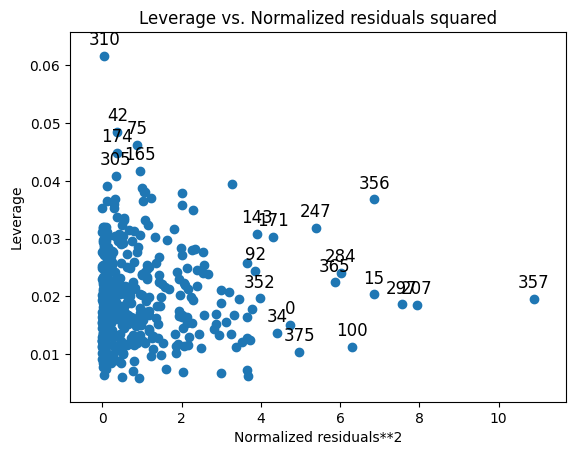

```python
# plot leverage plot for model from (e)
fig = plot_leverage_resid2(mlr_model_carseat_reduced)
```

The leverage plot shows that most observations have small leverage and residuals, lying within normal ranges. A few points like 42,75, 174, 165, 305 that have high leverage which are unusual predictor values potentially influencing the predictive performance. Points such as 357, 297, 207 have high residuals, meaning outliers due to poor predictions.

### 4.5 (a)

If the Bayes decision boundary is linear, do we expect LDA or QDA to perform bettr on the training set? On the test set?

Answer: Expect QDA to perform better than LDA on the training set becuase of higher flexibility of QDA as a result of fitting separate covariance matrix for each variable. However, since the true boundary is linear, QDA has greater risk of overfitting, while LDA models lineary boundaries directly. So LDA performs better than QDA on the test set.

### (b)

If the Bayes decision boundary is non-linear, do we expect LDA or QDA to perform better on the training set? On test set?

Answer: We expect QDA to perform better on both training and test set. QDA is more flexible and can fit to non-linear structure better while LDA is limited to linear boundary. QDA should also perform better on test set because LDA model result has higher variance as it fits a linear boundary mode on a non-linear boundary data.

### (c)

In general, as the sample size n increases, do we expect the test prediction accuracy of QDA relative to LDA to improve, decline, or be unchanged? why?

Answer: As the sample size increases, we expect the test prediction accuracy of QDA relative to LDA to improve. When sample size is small, QDA model is very noise as it creates more paraemters to fit the data, so the test variance is high. As data size increases, QDA's flexibility is more stable and can generalize to the unseen data better to capture the true boundary more accurately.

### (d)

True or false: Even if the Bayes decision boundary for a given problem is linear, we will probably achieve superior test error rate using QDA rather than LDA because QDA is flexible enough to model a linear decision boundary. Justify your answer.

Answer: False. If the true decision boundary is linear, LDA can still achieve lower test error because QDA estimates more parameters which leads to higher variance on the test data despite a linear boundary.

### 4.6 (a)

Estimate the probability that a student who studies for 40h and has an undergrad GPA of 3.5 gets an A in the class

Answer: $$ \log \frac{p}{1-p} = \beta_0 + \beta_1 X_1 + \beta_2 X_2 $$

$$ \beta_0 = -6, \quad \beta_1 = 0.05, \quad \beta_2 = 1 $$

$$ X_1 = 40 \text{ hours}, \quad X_2 = 3.5 \text{ GPA} $$

$$ \beta_0 + \beta_1 X_1 + \beta_2 X_2 = -6 + 0.05 \cdot 40 + 1 \cdot 3.5= -6 + 2 + 3.5 = -0.5 $$

$$ \log \frac{p}{1-p} = -0.5 $$

$$ p = 0.377 $$

The estimated probability that the student gets an A is about 38%

### 4.6 (b)

How many hours to have a 50% chance of getting an A

Answer: $$ \log \frac{p}{1-p} = -6 + 0.05 X_1 + 1 \cdot 3.5 = 0 $$

here $$ p = 0.5 $$

$$ 0 = -2.5 + 0.05 X_1 $$

Solve for X1:

$$ X_1 = \frac{2.5}{0.05} = 50 $$

The student needs to study 50 hours to have a 50% chance of getting an A.

### 4.12 (a)

Answer:

The log-odds of orange vs. apple is:

$$ \frac{p(x)}{1 - p(x)} = (\frac{\exp(\hat{\beta}_0 + \hat{\beta}_1 x)}{1+\exp(\hat{\beta}_0 + \hat{\beta}_1 x)})/(1-\frac{\exp(\hat{\beta}_0 + \hat{\beta}_1 x)}{1+\exp(\hat{\beta}_0 + \hat{\beta}_1 x)}) = \exp(\hat{\beta}_0 + \hat{\beta}_1 x) $$

Taking the log on both sides of the equation:

$$ \log \frac{p(x)}{1 - p(x)} = \hat{\beta}_0 + \hat{\beta}_1 x $$

Therefore, the log-odds of orange versus apple is $\hat{\beta}_0$ + $\hat{\beta}_1$.

### (b)

Answer:

given: $$ \Pr(Y=\text{orange} \mid X=x) = \frac{\exp(\hat{\alpha}_{\text{orange}0} + \hat{\alpha}_{\text{orange}1} x)} {\exp(\hat{\alpha}_{\text{orange}0} + \hat{\alpha}_{\text{orange}1} x) + \exp(\hat{\alpha}_{\text{apple}0} + \hat{\alpha}_{\text{apple}1} x)} $$

so,

$$ \Pr(Y=\text{apple} \mid X=x) = \frac{\exp(\hat{\alpha}_{\text{apple}0} + \hat{\alpha}_{\text{apple}1} x)} {\exp(\hat{\alpha}_{\text{orange}0} + \hat{\alpha}_{\text{orange}1} x) + \exp(\hat{\alpha}_{\text{apple}0} + \hat{\alpha}_{\text{apple}1} x)} $$

$$ \frac{\Pr(Y=\text{orange} \mid X=x)} {\Pr(Y=\text{apple} \mid X=x)} = \frac{\exp(\hat{\alpha}_{\text{orange}0} + \hat{\alpha}_{\text{orange}1} x)} {\exp(\hat{\alpha}_{\text{apple}0} + \hat{\alpha}_{\text{apple}1} x)} $$

$$ = \exp\left( (\hat{\alpha}_{\text{orange}0} - \hat{\alpha}_{\text{apple}0}) + (\hat{\alpha}_{\text{orange}1} - \hat{\alpha}_{\text{apple}1}) x \right) $$

Taking the log on both sides

$$ \log \frac{\Pr(Y=\text{orange} \mid X=x)} {\Pr(Y=\text{apple} \mid X=x)} = (\hat{\alpha}_{\text{orange}0} - \hat{\alpha}_{\text{apple}0}) + (\hat{\alpha}_{\text{orange}1} - \hat{\alpha}_{\text{apple}1}) x. $$

Therefore, the log-odds of orange versus apple is $$ (\hat{\alpha}_{\text{orange}0} - \hat{\alpha}_{\text{apple}0}) + (\hat{\alpha}_{\text{orange}1} - \hat{\alpha}_{\text{apple}1}) x. $$

### (c)

Answer:

From part (b), the log-odds in my friend's model is

$$ (\hat{\alpha}_{\text{orange}0} - \hat{\alpha}_{\text{apple}0}) + (\hat{\alpha}_{\text{orange}1} - \hat{\alpha}_{\text{apple}1}) x $$

In my model, the log-odds is

$$ \hat{\beta}_0 + \hat{\beta}_1 x = 2 - 1 \cdot x $$

So

$$ \hat{\beta}_0 = \hat{\alpha}_{\text{orange}0} - \hat{\alpha}_{\text{apple}0} = 2 $$

$$ \hat{\beta}_1 = \hat{\alpha}_{\text{orange}1} - \hat{\alpha}_{\text{apple}1} = -1 $$

Set apple class: $$ \hat{\alpha}_{\text{apple}0} = 0, \hat{\alpha}_{\text{apple}1} = 0\ $$

Then the coefficients for my friend's model are

$$ \hat{\alpha}_{\text{orange}0} = 2, \quad \hat{\alpha}_{\text{orange}1} = -1 $$

$$ \hat{\alpha}_{\text{apple}0} = 0, \quad \hat{\alpha}_{\text{apple}1} = 0 $$

### (d)

Answer:

Known $$ \hat{\beta}_0 = \hat{\alpha}_{\text{orange}0} - \hat{\alpha}_{\text{apple}0} = 2 $$

$$ \hat{\beta}_1 = \hat{\alpha}_{\text{orange}1} - \hat{\alpha}_{\text{apple}1} = -1 $$

Given $$ \hat{\alpha}_{\text{apple}0} = 0, \hat{\alpha}_{\text{apple}1} = 0\ $$

Then the coefficients for my model are

$$ \hat{\alpha}_{\text{orange}0} = 1.2, \hat{\alpha}_{\text{orange}1} = -2, \hat{\alpha}_{\text{apple}0} = 3, \hat{\alpha}_{\text{apple}1} = 0.6 $$

Therefore $$ \hat{\beta}_0 = \hat{\alpha}_{\text{orange}0} - \hat{\alpha}_{\text{apple}0} = 1.2-3=-1.8 $$

$$ \hat{\beta}_1 = \hat{\alpha}_{\text{orange}1} - \hat{\alpha}_{\text{apple}1} = -2-0.6=-2.6 $$

### (e)

Answer:

From (a), my model log-odds orange vs. apple is: $$ \log \frac{p(x)}{1 - p(x)} = \hat{\beta}_0 + \hat{\beta}_1 x $$

From (d), $$ \hat{\beta}_0 = -1.8, \hat{\beta}_1=-2.6 $$

so, my model log-odds of orange vs. apple is $$ -1.8 -2.6 x \rightarrow (i) $$

From (b), my friend's model, the log-odds of orange vs. apple is $$ (\hat{\alpha}_{\text{orange}0} - \hat{\alpha}_{\text{apple}0}) + (\hat{\alpha}_{\text{orange}1} - \hat{\alpha}_{\text{apple}1}) x. $$

Given $$ \hat{\alpha}_{\text{orange}0} = 1.2, \hat{\alpha}_{\text{orange}1} = -2, \hat{\alpha}_{\text{apple}0} = 3, \hat{\alpha}_{\text{apple}1} = 0.6 $$

The log-odds of orange vs. apple in my friend's model is: $$ 1.2-3 + (-2+0.6)x = -1.8 -2.6 x \rightarrow (ii) $$

We can see the log-odds of my model (i) = my friend's model log-odds (ii). It's expected the fraction of agreement is almost 100%

### 4.13 (a)

```python
# load Weekly data
from ISLP import load_data

Weekly = load_data("Weekly")
Weekly.head()
```

|  | Year | Lag1 | Lag2 | Lag3 | Lag4 | Lag5 | Volume | Today | Direction |
| --- | --- | --- | --- | --- | --- | --- | --- | --- | --- |
| 0 | 1990 | 0.816 | 1.572 | -3.936 | -0.229 | -3.484 | 0.154976 | -0.270 | Down |
| 1 | 1990 | -0.270 | 0.816 | 1.572 | -3.936 | -0.229 | 0.148574 | -2.576 | Down |
| 2 | 1990 | -2.576 | -0.270 | 0.816 | 1.572 | -3.936 | 0.159837 | 3.514 | Up |
| 3 | 1990 | 3.514 | -2.576 | -0.270 | 0.816 | 1.572 | 0.161630 | 0.712 | Up |
| 4 | 1990 | 0.712 | 3.514 | -2.576 | -0.270 | 0.816 | 0.153728 | 1.178 | Up |

```python
# EDA of the data

# describe data
display(Weekly.describe())

# aggregate data by year
year_agg = Weekly.groupby('Year').agg(
  volume_mean = ('Volume', 'mean'),
  volume_min = ('Volume', 'min'),
  volume_max = ('Volume', 'max'),
  today_mean = ('Today','mean'),
  today_min = ('Today', 'min'),
  today_max = ('Today', 'max'),
  pct_up_weeks = ('Direction', lambda x: (x=='Up').mean())
)

year_agg = year_agg.reset_index()
year_agg
```

|  | Year | Lag1 | Lag2 | Lag3 | Lag4 | Lag5 | Volume | Today |
| --- | --- | --- | --- | --- | --- | --- | --- | --- |
| count | 1089.000000 | 1089.000000 | 1089.000000 | 1089.000000 | 1089.000000 | 1089.000000 | 1089.000000 | 1089.000000 |
| mean | 2000.048669 | 0.150585 | 0.151079 | 0.147205 | 0.145818 | 0.139893 | 1.574618 | 0.149899 |
| std | 6.033182 | 2.357013 | 2.357254 | 2.360502 | 2.360279 | 2.361285 | 1.686636 | 2.356927 |
| min | 1990.000000 | -18.195000 | -18.195000 | -18.195000 | -18.195000 | -18.195000 | 0.087465 | -18.195000 |
| 25% | 1995.000000 | -1.154000 | -1.154000 | -1.158000 | -1.158000 | -1.166000 | 0.332022 | -1.154000 |
| 50% | 2000.000000 | 0.241000 | 0.241000 | 0.241000 | 0.238000 | 0.234000 | 1.002680 | 0.241000 |
| 75% | 2005.000000 | 1.405000 | 1.409000 | 1.409000 | 1.409000 | 1.405000 | 2.053727 | 1.405000 |
| max | 2010.000000 | 12.026000 | 12.026000 | 12.026000 | 12.026000 | 12.026000 | 9.328214 | 12.026000 |

|  | Year | volume_mean | volume_min | volume_max | today_mean | today_min | today_max | pct_up_weeks |
| --- | --- | --- | --- | --- | --- | --- | --- | --- |
| 0 | 1990 | 0.154797 | 0.087465 | 0.209816 | -0.058894 | -4.978 | 4.150 | 0.510638 |
| 1 | 1991 | 0.178047 | 0.130670 | 0.259656 | 0.532519 | -2.668 | 5.393 | 0.596154 |
| 2 | 1992 | 0.202925 | 0.169110 | 0.280922 | 0.081058 | -2.029 | 3.064 | 0.557692 |
| 3 | 1993 | 0.264237 | 0.176867 | 0.314235 | 0.136712 | -2.653 | 2.313 | 0.596154 |
| 4 | 1994 | 0.290375 | 0.201236 | 0.352498 | -0.020615 | -3.414 | 3.076 | 0.519231 |
| 5 | 1995 | 0.344762 | 0.241088 | 0.441864 | 0.570308 | -1.321 | 2.252 | 0.692308 |
| 6 | 1996 | 0.407590 | 0.254215 | 0.529728 | 0.382472 | -2.920 | 4.181 | 0.603774 |
| 7 | 1997 | 0.523199 | 0.366655 | 0.804848 | 0.534231 | -3.506 | 6.219 | 0.538462 |
| 8 | 1998 | 0.668851 | 0.444167 | 0.937900 | 0.478596 | -5.184 | 7.317 | 0.634615 |
| 9 | 1999 | 0.807698 | 0.607868 | 1.091880 | 0.376058 | -6.632 | 5.771 | 0.576923 |
| 10 | 2000 | 1.024906 | 0.574918 | 1.294680 | -0.156250 | -10.538 | 7.202 | 0.442308 |
| 11 | 2001 | 1.223764 | 0.756117 | 1.950082 | -0.180827 | -11.050 | 7.780 | 0.480769 |
| 12 | 2002 | 1.423000 | 0.762477 | 2.337088 | -0.449788 | -7.992 | 5.874 | 0.423077 |
| 13 | 2003 | 1.383011 | 0.817782 | 1.652340 | 0.403885 | -4.478 | 7.503 | 0.653846 |
| 14 | 2004 | 1.424179 | 1.033194 | 1.761040 | 0.182442 | -3.426 | 3.183 | 0.538462 |
| 15 | 2005 | 1.904059 | 0.889520 | 2.488110 | 0.065846 | -3.266 | 3.053 | 0.576923 |
| 16 | 2006 | 2.382995 | 1.447217 | 2.989828 | 0.254923 | -2.788 | 3.085 | 0.557692 |
| 17 | 2007 | 3.181802 | 1.541113 | 5.342306 | 0.010453 | -4.899 | 3.544 | 0.547170 |
| 18 | 2008 | 4.999577 | 3.087105 | 9.328214 | -0.683712 | -18.195 | 12.026 | 0.442308 |
| 19 | 2009 | 5.574445 | 3.013263 | 7.963276 | 0.406462 | -7.035 | 10.707 | 0.557692 |
| 20 | 2010 | 4.557765 | 2.390427 | 7.683886 | 0.260135 | -6.388 | 5.416 | 0.615385 |

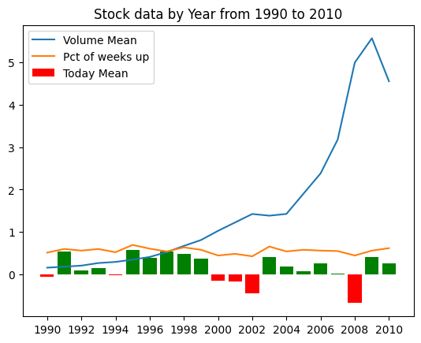

```python
# graph the aggregated yearly data
import matplotlib.pyplot as plt

plt.plot(year_agg['Year'], year_agg['volume_mean'], label = 'Volume Mean')
colors = ['green' if val >= 0 else 'red' for val in year_agg['today_mean']]
plt.bar(year_agg['Year'], year_agg['today_mean'], color=colors, label='Today Mean')
plt.plot(year_agg['Year'], year_agg['pct_up_weeks'], label = 'Pct of weeks up')
plt.title('Stock data by Year from 1990 to 2010')
plt.legend()
plt.xticks(range(1990, 2011, 2));
```

### (b) Logistic Model

```python
# logistic regression

import statsmodels.api as sm
Weekly['direction_encode'] = Weekly['Direction'].map({'Up': 1, 'Down': 0 }) # transform 'up' as 1 and 'down' as 0
x = Weekly[['Lag1','Lag2','Lag3','Lag4','Lag5','Volume']]
x = sm.add_constant(x) # add constant
y = Weekly['direction_encode']

# fit logit model
logit_model = sm.Logit(y, x)
logit_model_result = logit_model.fit()
logit_model_result.summary()
```

```
Optimization terminated successfully.
         Current function value: 0.682441
         Iterations 4
```

Logit Regression Results

| Dep. Variable: | direction_encode | No. Observations: | 1089 |
| --- | --- | --- | --- |
| Model: | Logit | Df Residuals: | 1082 |
| Method: | MLE | Df Model: | 6 |
| Date: | Sun, 22 Feb 2026 | Pseudo R-squ.: | 0.006580 |
| Time: | 20:27:54 | Log-Likelihood: | -743.18 |
| converged: | True | LL-Null: | -748.10 |
| Covariance Type: | nonrobust | LLR p-value: | 0.1313 |

|  | coef | std err | z | P>\|z\| | [0.025 | 0.975] |
| --- | --- | --- | --- | --- | --- | --- |
| const | 0.2669 | 0.086 | 3.106 | 0.002 | 0.098 | 0.435 |
| Lag1 | -0.0413 | 0.026 | -1.563 | 0.118 | -0.093 | 0.010 |
| Lag2 | 0.0584 | 0.027 | 2.175 | 0.030 | 0.006 | 0.111 |
| Lag3 | -0.0161 | 0.027 | -0.602 | 0.547 | -0.068 | 0.036 |
| Lag4 | -0.0278 | 0.026 | -1.050 | 0.294 | -0.080 | 0.024 |
| Lag5 | -0.0145 | 0.026 | -0.549 | 0.583 | -0.066 | 0.037 |
| Volume | -0.0227 | 0.037 | -0.616 | 0.538 | -0.095 | 0.050 |

The logistic regression result shows that only Lag2 is statistically significant (p = 0.03). All other predictors have p-values greater than 0.05 and are not significant. The pseudo R-squared is very low (0.0066), suggesting that the model explains very little of the variation in weekly market direction.

### (c)

```python
# make predictions
pred_prob = logit_model_result.predict(x)

# convert >=0.5 as "up" and <0.5 as "down"
Weekly['direction_pred'] = ["Up" if x>=0.5 else 'Down' for x in pred_prob]
```

```python
# plot confusion matrix
from sklearn.metrics import confusion_matrix, accuracy_score, ConfusionMatrixDisplay

# overall accuracy
accuracy = accuracy_score(Weekly['Direction'], Weekly['direction_pred'])
print("Overall accuracy of the logistic model using five lag variables and Volume", accuracy)
```

```
Overall accuracy of the logistic model using five lag variables and Volume 0.5610651974288338
```

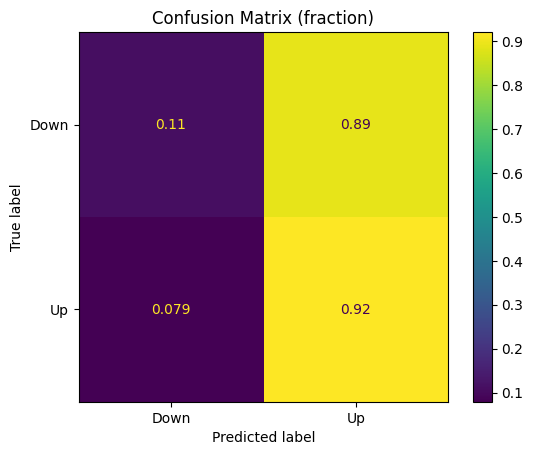

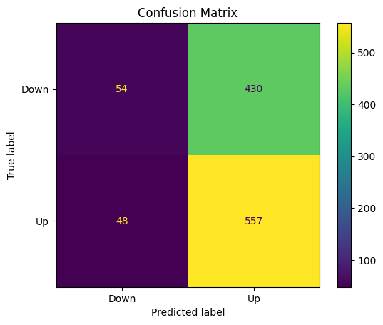

```python
# plot confusion matrix
disp_frac = ConfusionMatrixDisplay.from_predictions(
    Weekly['Direction'],
    Weekly['direction_pred'],
    normalize="true"
)

plt.title("Confusion Matrix (fraction)")
plt.show();

disp = ConfusionMatrixDisplay.from_predictions(
    Weekly['Direction'],
    Weekly['direction_pred']
)
plt.title("Confusion Matrix")
plt.show();
```

The confusion matrix shows the logistic model predicts majority of the observations as "Up" (90%). Although the Recall rate on "Up" is high (92%), the Precision (56%) on "Up" is low. Both the Recall rate (11%) and Precision (54%) on "Down" is low accordingly. Overall, due to the biases prediction towards "Up", the model shows low accuracy score.

### (d) Logistic model on Lag2 predictor

```python
# train, test data
train = Weekly[(Weekly['Year']>=1990) & (Weekly['Year']<=2008)]
test = Weekly[Weekly['Year']>2008]
```

```python
# fit logistic model using train data
logit_model2 = sm.Logit(train['direction_encode'], train['Lag2'])
logit_model_result2 = logit_model2.fit() # fit model using lag2

# print model summary
logit_model_result2.summary()
```

```
Optimization terminated successfully.
         Current function value: 0.690654
         Iterations 4
```

Logit Regression Results

| Dep. Variable: | direction_encode | No. Observations: | 985 |
| --- | --- | --- | --- |
| Model: | Logit | Df Residuals: | 984 |
| Method: | MLE | Df Model: | 0 |
| Date: | Sat, 21 Feb 2026 | Pseudo R-squ.: | -0.004340 |
| Time: | 16:24:40 | Log-Likelihood: | -680.29 |
| converged: | True | LL-Null: | -677.35 |
| Covariance Type: | nonrobust | LLR p-value: | nan |

|  | coef | std err | z | P>\|z\| | [0.025 | 0.975] |
| --- | --- | --- | --- | --- | --- | --- |
| Lag2 | 0.0629 | 0.029 | 2.192 | 0.028 | 0.007 | 0.119 |

```python
# predict using test data
pred_prob2 = logit_model_result2.predict(test['Lag2'])

# convert >=0.5 as "up" and <0.5 as "down"
test['direction_pred'] = ["Up" if x>=0.5 else 'Down' for x in pred_prob2]
```

```python
# overall accuracy
accuracy2 = accuracy_score(test['Direction'], test['direction_pred'])
print("Overall accuracy of the logistic model using five lag variables and Volume", accuracy2)
```

```
Overall accuracy of the logistic model using five lag variables and Volume 0.5480769230769231
```

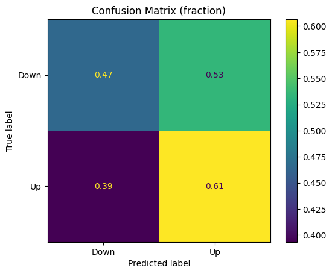

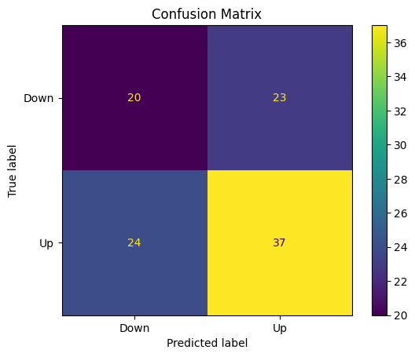

```python
# plot confusion matrix
disp_frac = ConfusionMatrixDisplay.from_predictions(
    test['Direction'],
    test['direction_pred'],
    normalize="true"
)

plt.title("Confusion Matrix (fraction)")
plt.show();

disp = ConfusionMatrixDisplay.from_predictions(
    test['Direction'],
    test['direction_pred']
)
plt.title("Confusion Matrix")
plt.show();
```

Using Lag2 as the only predictor and training on 1990–2008, the logistic regression model achieves an accuracy of approximately 54.8% on the 2009–2010 test data. The confusion matrix shows that the model performs better at predicting Up weeks (60.7% correct) than Down weeks (46.5% correct). Overall, predictive performance is only slightly better than random guessing, indicating weak predictive performance. The overall accuracy is lower than the original model.

### (e) LDA

```python
from sklearn.discriminant_analysis import LinearDiscriminantAnalysis

x_train = train[['Lag2']]
x_test  = test[['Lag2']]

y_train = train['direction_encode']
y_test  = test['direction_encode']

# train LDA
lda_model = LinearDiscriminantAnalysis()
lda_model.fit(x_train, y_train)

# prediction
y_pred_lda = lda_model.predict(x_test)

# add lda pred to the test data
test['direction_pred_lda'] = ["Up" if x==1 else 'Down' for x in y_pred_lda]
```

```python
# overall accuracy of LDA model
accuracy_lda = accuracy_score(test['Direction'], test['direction_pred_lda'])
print("Overall accuracy of the LDA model using Lag2 only", accuracy_lda)
```

```
Overall accuracy of the LDA model using Lag2 only 0.625
```

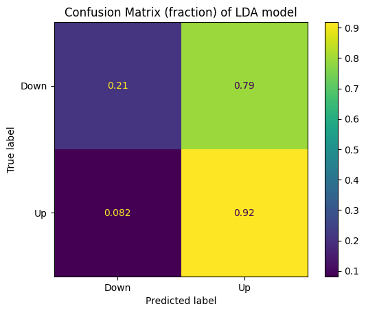

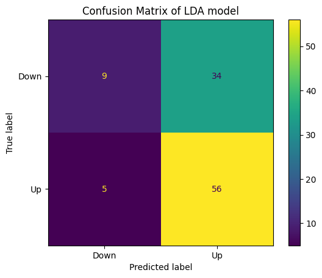

```python
# plot confusion matrix of LDA model
disp_frac_lda = ConfusionMatrixDisplay.from_predictions(
    test['Direction'],
    test['direction_pred_lda'],
    normalize="true"
)

plt.title("Confusion Matrix (fraction) of LDA model")
plt.show();

disp = ConfusionMatrixDisplay.from_predictions(
    test['Direction'],
    test['direction_pred_lda']
)
plt.title("Confusion Matrix of LDA model")
plt.show();
```

The LDA model shows a slightly higher overall accuracy (62.5%) then the logistic model, however, still majority of the observations in the test data set are predicted as "Up". Thus, "Up" has high Recall rate but low Precision. "Down" category has both low Recall and Precision.

### (f) QDA

```python
from sklearn.discriminant_analysis import QuadraticDiscriminantAnalysis

# train QDA
qda_model = QuadraticDiscriminantAnalysis()
qda_model.fit(x_train, y_train)

# prediction
y_pred_qda = qda_model.predict(x_test)

# add qda pred to the test data
test['direction_pred_qda'] = ["Up" if x==1 else 'Down' for x in y_pred_qda]
```

```python
# overall accuracy of QDA model
accuracy_qda = accuracy_score(test['Direction'], test['direction_pred_qda'])
print("Overall accuracy of the QDA model using Lag2 only", accuracy_qda)
```

```
Overall accuracy of the QDA model using Lag2 only 0.5865384615384616
```

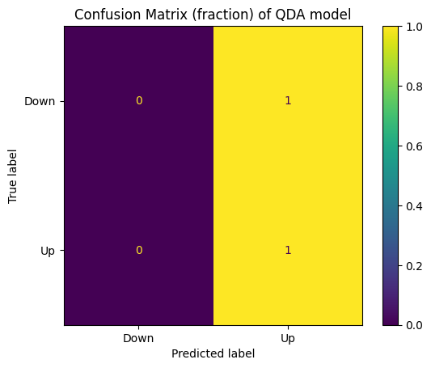

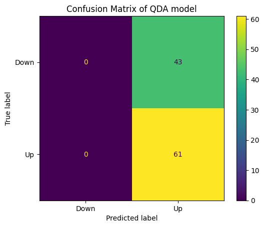

```python
# plot confusion matrix of QDA model
disp_frac_qda = ConfusionMatrixDisplay.from_predictions(
    test['Direction'],
    test['direction_pred_qda'],
    normalize="true"
)

plt.title("Confusion Matrix (fraction) of QDA model")
plt.show();

disp = ConfusionMatrixDisplay.from_predictions(
    test['Direction'],
    test['direction_pred_qda']
)
plt.title("Confusion Matrix of QDA model")
plt.show();
```

### (g) KNN

```python
# for KNN, use Direction categorical column instead of transformed Direction as y
y_train_t = train['Direction']
y_test_t  = test['Direction']
```

```python
from sklearn.neighbors import KNeighborsClassifier
# fit KNN model
knn_model = KNeighborsClassifier(n_neighbors=1)
knn_model.fit(x_train, y_train_t)

# prediction
y_pred_knn = knn_model.predict(x_test)

# add knn pred to the test data
test['direction_pred_knn'] = y_pred_knn
```

```python
# overall accuracy of KNN model
accuracy_knn = accuracy_score(test['Direction'], test['direction_pred_knn'])
print("Overall accuracy of the KNN model using Lag2 only", accuracy_knn)
```

```
Overall accuracy of the KNN model using Lag2 only 0.5
```

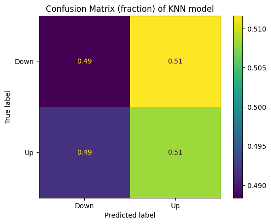

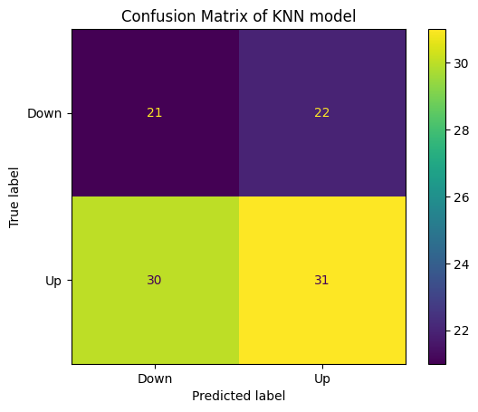

```python
# plot confusion matrix of KNN model
disp_frac_knn = ConfusionMatrixDisplay.from_predictions(
    test['Direction'],
    test['direction_pred_knn'],
    normalize="true"
)

plt.title("Confusion Matrix (fraction) of KNN model")
plt.show();

disp = ConfusionMatrixDisplay.from_predictions(
    test['Direction'],
    test['direction_pred_knn']
)
plt.title("Confusion Matrix of KNN model")
plt.show();
```

The overall accuracy of KNN model is 50%. The prediction is more evently distributed between "Up" and "Down", but no meaningful improvement than random guess.

### (h) Naive Bayes

```python
from sklearn.naive_bayes import GaussianNB

# fit NB model
nb = GaussianNB()
nb_model = nb.fit(x_train, y_train_t)

# prediction
y_pred_nb = nb_model.predict(x_test)

# add NB pred to the test data
test['direction_pred_nb'] = y_pred_nb
```

```python
# overall accuracy of NB model
accuracy_nb = accuracy_score(test['Direction'], test['direction_pred_nb'])
print("Overall accuracy of the NB model using Lag2 only", accuracy_nb)
```

```
Overall accuracy of the NB model using Lag2 only 0.5865384615384616
```

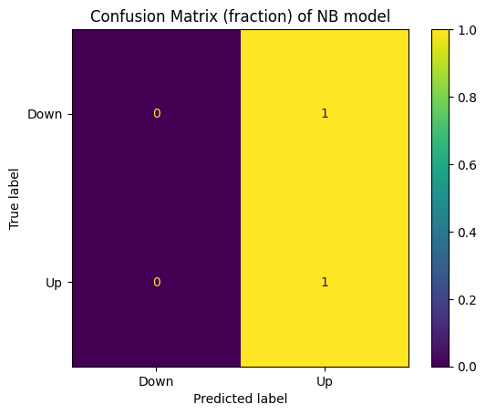

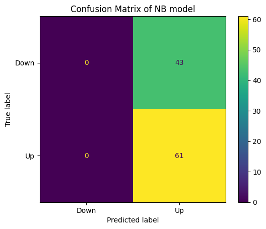

```python
# plot confusion matrix of NB model
disp_frac_nb = ConfusionMatrixDisplay.from_predictions(
    test['Direction'],
    test['direction_pred_nb'],
    normalize="true"
)

plt.title("Confusion Matrix (fraction) of NB model")
plt.show();

disp = ConfusionMatrixDisplay.from_predictions(
    test['Direction'],
    test['direction_pred_nb']
)
plt.title("Confusion Matrix of NB model")
plt.show();
```

The Naive Bayes performance is very close to the result of QDA

### (i)

Comparing Logistic Regression, LDA, QDA, KNN, and Naive Bayes models results, LDA model with Lag2 as predictor provides the best result with highest accuracy as 62.5%. However, LDA also has high Type1 and Type2 error. In fact, none of these models trained above shows satisfying result, partially due to the selection of the predictor.

### (j)

Experiment different predictors excluding interactions and tranformation

```python
import pandas as pd
import statsmodels.api as sm
from sklearn.discriminant_analysis import LinearDiscriminantAnalysis
from sklearn.discriminant_analysis import QuadraticDiscriminantAnalysis
from sklearn.naive_bayes import GaussianNB
from sklearn.neighbors import KNeighborsClassifier
from sklearn.metrics import accuracy_score
from sklearn.metrics import confusion_matrix, ConfusionMatrixDisplay

# create empty dictionary to store models results
results = {'predictors': [], 'model': [], 'accuracy': []}

predictor_list = [['Lag1'], ['Lag2'],['Lag3'],['Lag4'],['Lag5'], ['Volume'],
                  ['Lag1', 'Lag2'], ['Lag1', 'Lag3'], ['Lag1', 'Lag4'],['Lag1', 'Lag5'], ['Lag1', 'Volume'], ['Lag2', 'Lag3'],['Lag2', 'Lag4'],['Lag2', 'Lag5'],['Lag2', 'Volume'],['Lag3', 'Lag4'],['Lag3', 'Lag5'],['Lag3', 'Volume'],['Lag4', 'Lag5'],['Lag4', 'Volume'], ['Lag5', 'Volume'],
                  ['Lag1', 'Lag2','Lag3'],['Lag1', 'Lag2','Lag4'],['Lag1', 'Lag2','Lag5'],['Lag1', 'Lag2','Volume'],['Lag2', 'Lag3','Lag4'],['Lag2', 'Lag3','Lag5'],['Lag2', 'Lag3','Volume'],['Lag3', 'Lag4','Lag5'], ['Lag3', 'Lag4','Volume'],['Lag4', 'Lag5','Volume'],
                  ['Lag1', 'Lag2','Lag3','Lag4'], ['Lag1', 'Lag2','Lag3','Lag5'], ['Lag1', 'Lag2','Lag3','Volume'], ['Lag1', 'Lag2','Lag4','Lag5'], ['Lag1', 'Lag2','Lag4','Volume'],['Lag1', 'Lag2','Lag5','Volume'],['Lag1', 'Lag3','Lag4','Lag5'],['Lag1', 'Lag3','Lag4','Volume'],['Lag1', 'Lag3','Lag5','Volume'], ['Lag2', 'Lag3','Lag4','Lag5'],['Lag2', 'Lag3','Lag4','Volume'],['Lag2', 'Lag3','Lag5','Volume'],['Lag2', 'Lag4','Lag5','Volume'],
                  ['Lag1', 'Lag2','Lag3','Lag4','Lag5'],['Lag1', 'Lag2','Lag4','Lag5','Volume'],['Lag2', 'Lag3','Lag4','Lag5','Volume'],
                  ['Lag1', 'Lag2','Lag3','Lag4','Lag5','Volume']
                  ]

for p in predictor_list:
    predictors_str = "+".join(p)

    # train/test split
    train = Weekly[(Weekly['Year'] >= 1990) & (Weekly['Year'] <= 2008)].copy()
    test = Weekly[Weekly['Year'] > 2008].copy()

    x_train = train[p]
    x_test = test[p]

    # add constant for logistic regression
    x_train_const = sm.add_constant(x_train)
    x_test_const = sm.add_constant(x_test)

    # transform y for logistic regression
    y_train_c = [1 if d == 'Up' else 0 for d in train['Direction']]

    ######### Logistic Regression #########
    logit_model = sm.Logit(y_train_c, x_train_const)
    logit_result = logit_model.fit(disp=False)

    pred_prob = logit_result.predict(x_test_const)
    pred_label = ["Up" if x >= 0.5 else "Down" for x in pred_prob]
    accuracy = accuracy_score(test['Direction'], pred_label)

    results['predictors'].append(predictors_str)
    results['model'].append('Logistic')
    results['accuracy'].append(accuracy)

    ######### LDA #########
    lda_model = LinearDiscriminantAnalysis()
    lda_model.fit(x_train, train['Direction'])

    y_pred_lda = lda_model.predict(x_test)
    accuracy_lda = accuracy_score(test['Direction'], y_pred_lda)

    results['predictors'].append(predictors_str)
    results['model'].append('LDA')
    results['accuracy'].append(accuracy_lda)

    ######### QDA #########
    qda_model = QuadraticDiscriminantAnalysis()
    qda_model.fit(x_train, train['Direction'])

    y_pred_qda = qda_model.predict(x_test)
    accuracy_qda = accuracy_score(test['Direction'], y_pred_qda)

    results['predictors'].append(predictors_str)
    results['model'].append('QDA')
    results['accuracy'].append(accuracy_qda)

    ######### KNN (k=1) #########
    knn1_model = KNeighborsClassifier(n_neighbors=1)
    knn1_model.fit(x_train, train['Direction'])

    y_pred_knn1 = knn1_model.predict(x_test)
    accuracy_knn1 = accuracy_score(test['Direction'], y_pred_knn1)

    results['predictors'].append(predictors_str)
    results['model'].append('KNN (k=1)')
    results['accuracy'].append(accuracy_knn1)

    ######### KNN (k=2) #########
    knn2_model = KNeighborsClassifier(n_neighbors=2)
    knn2_model.fit(x_train, train['Direction'])

    y_pred_knn2 = knn2_model.predict(x_test)
    accuracy_knn2 = accuracy_score(test['Direction'], y_pred_knn2)

    results['predictors'].append(predictors_str)
    results['model'].append('KNN (k=2)')
    results['accuracy'].append(accuracy_knn2)

    ######### KNN (k=3) #########
    knn3_model = KNeighborsClassifier(n_neighbors=3)
    knn3_model.fit(x_train, train['Direction'])

    y_pred_knn3 = knn3_model.predict(x_test)
    accuracy_knn3 = accuracy_score(test['Direction'], y_pred_knn3)

    results['predictors'].append(predictors_str)
    results['model'].append('KNN (k=3)')
    results['accuracy'].append(accuracy_knn3)

    ######### KNN (k=4) #########
    knn4_model = KNeighborsClassifier(n_neighbors=4)
    knn4_model.fit(x_train, train['Direction'])

    y_pred_knn4 = knn4_model.predict(x_test)
    accuracy_knn4 = accuracy_score(test['Direction'], y_pred_knn4)

    results['predictors'].append(predictors_str)
    results['model'].append('KNN (k=4)')
    results['accuracy'].append(accuracy_knn4)

    ######### KNN (k=5) #########
    knn5_model = KNeighborsClassifier(n_neighbors=5)
    knn5_model.fit(x_train, train['Direction'])

    y_pred_knn5 = knn5_model.predict(x_test)
    accuracy_knn5 = accuracy_score(test['Direction'], y_pred_knn5)

    results['predictors'].append(predictors_str)
    results['model'].append('KNN (k=5)')
    results['accuracy'].append(accuracy_knn5)

    ######### Naive Bayes #########
    nb_model = GaussianNB()
    nb_model.fit(x_train, train['Direction'])

    y_pred_nb = nb_model.predict(x_test)
    accuracy_nb = accuracy_score(test['Direction'], y_pred_nb)

    results['predictors'].append(predictors_str)
    results['model'].append('NB')
    results['accuracy'].append(accuracy_nb)

# convert to DataFrame
results_df = pd.DataFrame(results)
```

```python
print(results_df)
```

```
                          predictors      model  accuracy
0                               Lag1   Logistic  0.567308
1                               Lag1        LDA  0.567308
2                               Lag1        QDA  0.586538
3                               Lag1  KNN (k=1)  0.442308
4                               Lag1  KNN (k=2)  0.451923
..                               ...        ...       ...
427  Lag1+Lag2+Lag3+Lag4+Lag5+Volume  KNN (k=2)  0.461538
428  Lag1+Lag2+Lag3+Lag4+Lag5+Volume  KNN (k=3)  0.509615
429  Lag1+Lag2+Lag3+Lag4+Lag5+Volume  KNN (k=4)  0.538462
430  Lag1+Lag2+Lag3+Lag4+Lag5+Volume  KNN (k=5)  0.500000
431  Lag1+Lag2+Lag3+Lag4+Lag5+Volume         NB  0.451923

[432 rows x 3 columns]
```

#### Step2: analyze the best model

```python
# get average accuracy for each model
best_model = results_df.loc[results_df['accuracy'].idxmax()]
print(best_model)
```

```
predictors        Lag2
model         Logistic
accuracy         0.625
Name: 9, dtype: object
```

The result shows logistic model with Lag2 as predictor has best accurcy result of 62.5%. Now fit model with Lag2 transformations and interactions with Volume

```python
import numpy as np
# create empty dictionary to store transformed and interactions models results
results2 = {'predictors': [], 'accuracy': []}

# 1. Lag2^2 as predictor
x_train = train['Lag2']**2
x_test = test['Lag2']**2

# add constant for logistic regression
x_train_const = sm.add_constant(x_train)
x_test_const = sm.add_constant(x_test)

# transform y for logistic regression
y_train_c = [1 if d == 'Up' else 0 for d in train['Direction']]

######### Logistic Regression #########
logit_model = sm.Logit(y_train_c, x_train_const)
logit_result = logit_model.fit(disp=False)

pred_prob = logit_result.predict(x_test_const)
pred_label = ["Up" if x >= 0.5 else "Down" for x in pred_prob]
accuracy = accuracy_score(test['Direction'], pred_label)

results2['predictors'].append('Lag2_sqr')
results2['accuracy'].append(accuracy)


# 2 log volume as predictor
x_train = np.log(train['Volume'])
x_test = np.log(test['Volume'])

# add constant for logistic regression
x_train_const = sm.add_constant(x_train)
x_test_const = sm.add_constant(x_test)

# transform y for logistic regression
y_train_c = [1 if d == 'Up' else 0 for d in train['Direction']]

######### Logistic Regression #########
logit_model = sm.Logit(y_train_c, x_train_const)
logit_result = logit_model.fit(disp=False)

pred_prob = logit_result.predict(x_test_const)
pred_label = ["Up" if x >= 0.5 else "Down" for x in pred_prob]
accuracy = accuracy_score(test['Direction'], pred_label)

results2['predictors'].append('Log(Volume)')
results2['accuracy'].append(accuracy)


# 3. lag2 * volume as predictor
x_train = train['Volume']* train['Lag2']
x_test = test['Volume']* test['Lag2']

# add constant for logistic regression
x_train_const = sm.add_constant(x_train)
x_test_const = sm.add_constant(x_test)

# transform y for logistic regression
y_train_c = [1 if d == 'Up' else 0 for d in train['Direction']]

######### Logistic Regression #########
logit_model = sm.Logit(y_train_c, x_train_const)
logit_result = logit_model.fit(disp=False)

pred_prob = logit_result.predict(x_test_const)
pred_label = ["Up" if x >= 0.5 else "Down" for x in pred_prob]
accuracy = accuracy_score(test['Direction'], pred_label)

results2['predictors'].append('Lag2 * Volume')
results2['accuracy'].append(accuracy)
```

```python
pd.DataFrame(results2)
```

|  | predictors | accuracy |
| --- | --- | --- |
| 0 | Lag2_sqr | 0.586538 |
| 1 | Log(Volume) | 0.586538 |
| 2 | Lag2 * Volume | 0.615385 |

The transformed results show transformed Lag2 and interaction predictor with Volume are both not performing better than Lag2 itself as single predictor